# Vignette Title

The ICE plot contains all sampled, individual observations in blue. The red line is from PDP.

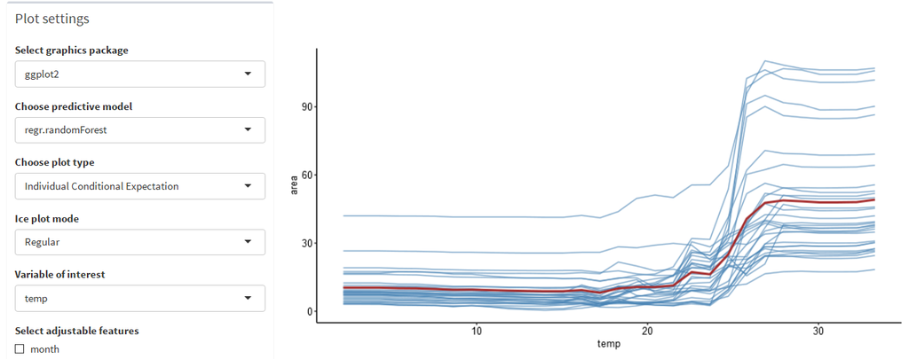

As described above, you can select between `Regular` and `Centered` ICE plots.

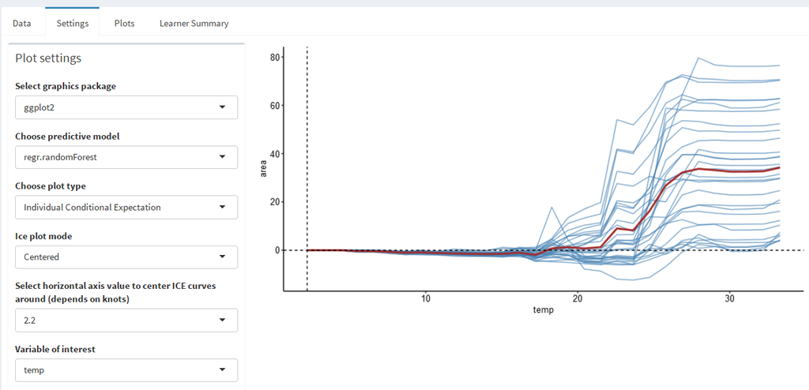

The ALE plot can be selected, too. Please keep in mind, that the ALE plot has a different y-axis than the PDP and ICE plot.

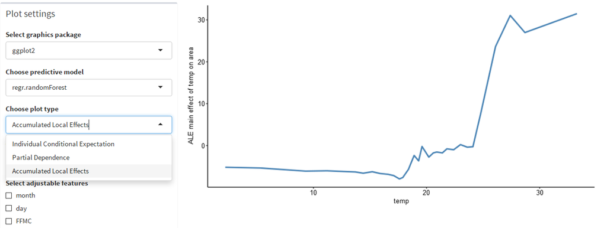

The third tab `Plots` shows the IML plot in full screen via the sub-tab `Zoomed plot`. The sub-tab `Scatterplot` shows the filtered and unfiltered scatterplot between the `variable of interest` and the `target` variable of the model.

In the `Data` tab we filtered for a high value of burned area and selected three individual observations.

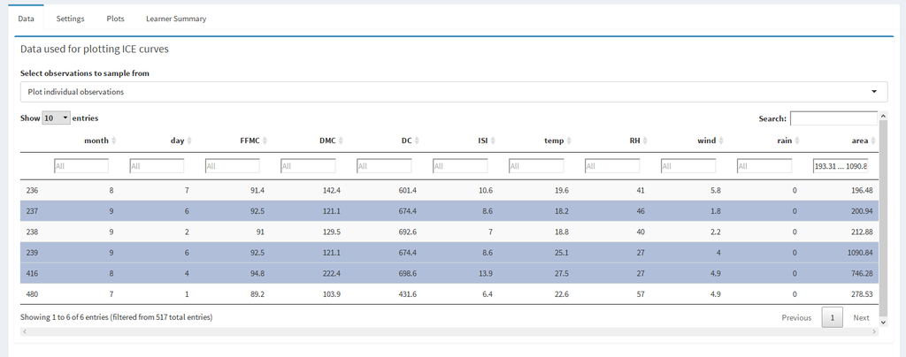

The filtered data scatterplot shows the selected high area values and also the three individual observations (in red).

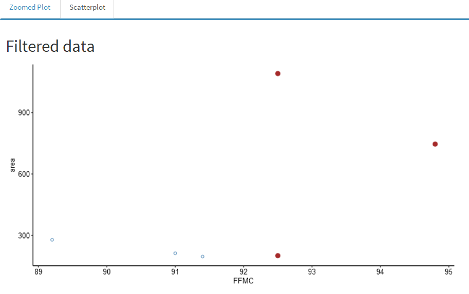

The fourth tab `Learner summary` shows the currently selected learner summary. If you want to see another summary, you have to select another model in the `Settings` tab.

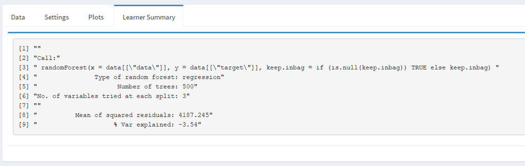

### Code for Copy & Paste

```r
fire.task = makeRegrTask(data = fire, target = "area")

fire.rf = train("regr.randomForest", fire.task)
fire.lm = train("regr.lm", fire.task)
fire.glm = train("regr.glm", fire.task)

fire.models = list(fire.rf, fire.lm, fire.glm)

imlplots(data = fire, task = fire.task, models = fire.models)
```

## IML Plots for Classification Tasks

For the classification example only the differences to the regression example will be explained. We use the titanic data set from [kaggle](https://www.kaggle.com/c/titanic) for this example.

Again we create a task. This time we only fit one random forest. Afterwards we open the app.

```r
titanic.task = makeClassifTask(data = titanic, target = "Survived")
titanic.rf = train("classif.randomForest", titanic.task)
imlplots(data = titanic, task = titanic.task, titanic.rf)
```

This time it is useful to select `plotly` in the `Select graphics package` dropdown.

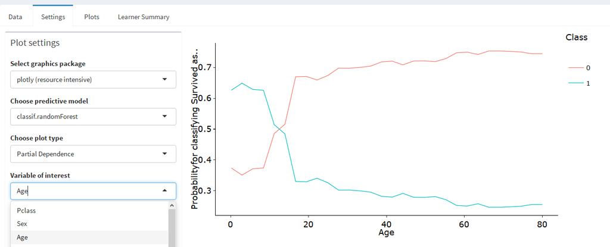

This allows you to deselect single classes to increase the visability of individual lines, which is very useful for ICE plot.

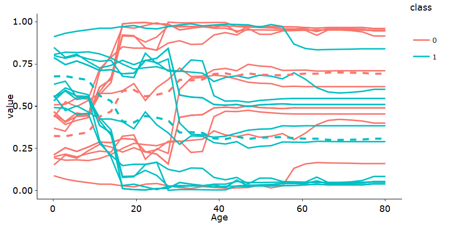

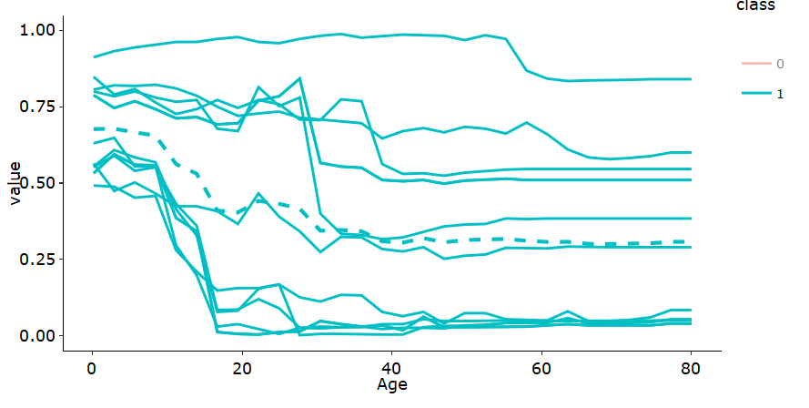

# References

- [PDP and ICE plots](https://arxiv.org/pdf/1309.6392.pdf)
- [mmpf R package](https://github.com/zmjones/mmpf)
- [ALE plots](https://arxiv.org/abs/1612.08468)
- [ALE R package](https://cran.r-project.org/web/packages/ALEPlot/index.html)